# 2021_Nottingham_Lockdown full R markdown

Samuel R.P-J. Ross

08/08/2021

This is the R markdown accompanying the manuscript *A suburban soundscape reveals altered acoustic dynamics during COVID-19 lockdown*. Here I will analyse the difference in acoustic indices during versus after COVID-19 lockdown using standardised effect sizes.

First, I’ll generate a stats output matrix:

```r
Stats_Out<-data.frame("Index"=rep(as.character(colnames(Standard)[c(2:12)]),each=6),
                      "Subset"=rep(c("All","Dawn","6am","Midnight","Midday","8am"),11),
                      'U'=NA,'p.val'=NA,"Diff"=NA,"Diff_lo"=NA,"Diff_up"=NA,'Lock_med'=NA,
                      'Lock_SD'=NA,'Post_med'=NA,'Post_SD'=NA,'Z'=NA,"Sig"=NA)
```

Now I can begin the analysis, first using all the data together, then on various temporal subsets.

## All data

```r
for (i in 1:length(unique(Stats_Out$Index))) {

  Data<-data.frame("Post_Index" = Standard[Standard$Period %in% "Post-lockdown",1+i],
                   "Lock_Index" = c(Standard[Standard$Period %in% "Lockdown",1+i],
                                    rep(NA,length(Standard[Standard$Period %in%
                                                             "Post-lockdown",1+i])-length(Standard[Standard$Period %in%
                                                                                                     "Lockdown",1+i]))))
  Wilcox.out<-wilcox.test(x = Data$Lock_Index,
                          y = Data$Post_Index,
                          na.rm=TRUE,
                          paired=TRUE,
                          exact=FALSE,
                          conf.int=TRUE,
                          digits.rank = 7)

  Stats_Out$U[Stats_Out$Subset %in% "All"][i]<-Wilcox.out$statistic
  Stats_Out$p.val[Stats_Out$Subset %in% "All"][i]<-Wilcox.out$p.value
  Stats_Out$Z[Stats_Out$Subset %in% "All"][i]<-qnorm(Wilcox.out$p.value/2)
  Stats_Out$Lock_med[Stats_Out$Subset %in% "All"][i]<-median(Data$Lock_Index,na.rm = T)
  Stats_Out$Lock_SD[Stats_Out$Subset %in% "All"][i]<-sd(Data$Lock_Index,na.rm = T)
  Stats_Out$Post_med[Stats_Out$Subset %in% "All"][i]<-median(Data$Post_Index,na.rm = T)
  Stats_Out$Post_SD[Stats_Out$Subset %in% "All"][i]<-sd(Data$Post_Index,na.rm = T)
  Stats_Out$Diff[Stats_Out$Subset %in% "All"][i]<-Wilcox.out$estimate
  Stats_Out$Diff_lo[Stats_Out$Subset %in% "All"][i]<-min(Wilcox.out$conf.int)
  Stats_Out$Diff_up[Stats_Out$Subset %in% "All"][i]<-max(Wilcox.out$conf.int)
}
```

Note that for AEve, it’s not immediately clear what’s driving the difference between periods, so I’ll dive a little deeper and present the results graphically in the supporting information (Fig. S3):

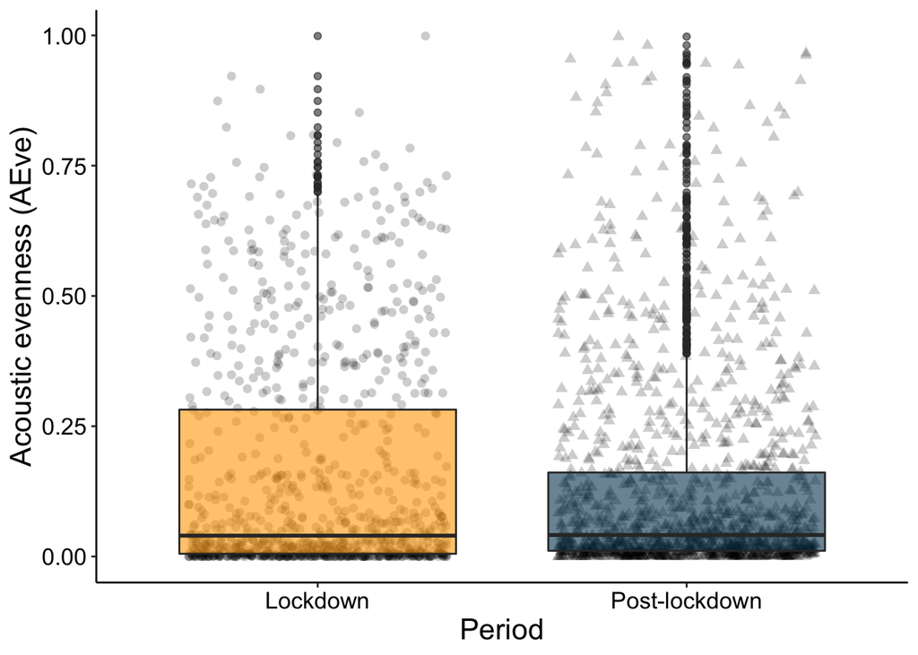

```r
ggplot(data = Standard,
       mapping = aes(x = Period,
                     y = AEve)) +
      ylab("Acoustic evenness (AEve)") +
      xlab("Period") +
      theme_classic() +
      theme(text = element_text(size = 16),
                axis.text = element_text(colour = "black"),
                strip.background = element_blank(),
                legend.position = "bottom") +
      geom_point(mapping = aes(shape = Period),
                     position = position_jitter(width = 0.35),
                     size = 2, alpha = 0.2,
                     show.legend = FALSE) +
      geom_boxplot(mapping = aes(fill = Period),
                       alpha = 0.6) +
      scale_shape_manual(values = c(16,17),
                             guide=FALSE) +
      scale_fill_manual(values = c('#ffa600','#003f5c'),guide = F)
```

Here, one can see that although the medians don’t seem to differ, many more of the points within the 75% quantile are higher during lockdown than post-lockdown.

## Dawn Chorus

Next, I’ll analyse the data from the subset of the full dataset that I cut down to be only those around sunrise (see Methods):

```r
for (i in 1:length(unique(Stats_Out$Index))) {

  Data<-data.frame("Post_Index" = Dawn.chorus[Dawn.chorus$Period %in% "Post-lockdown",1+i],
                   "Lock_Index" = c(Dawn.chorus[Dawn.chorus$Period %in% "Lockdown",1+i],
                                    rep(NA,length(Dawn.chorus[Dawn.chorus$Period %in%
                                                             "Post-lockdown",1+i])-length(Dawn.chorus[Dawn.chorus$Period %in%
                                                                                                     "Lockdown",1+i]))))
  Wilcox.out<-wilcox.test(x = Data$Lock_Index,
                          y = Data$Post_Index,
                          na.rm=TRUE,
                          paired=TRUE,
                          exact=FALSE,
                          conf.int=TRUE,
                          digits.rank = 7)

  Stats_Out$U[Stats_Out$Subset %in% "Dawn"][i]<-Wilcox.out$statistic
  Stats_Out$p.val[Stats_Out$Subset %in% "Dawn"][i]<-Wilcox.out$p.value
  Stats_Out$Z[Stats_Out$Subset %in% "Dawn"][i]<-qnorm(Wilcox.out$p.value/2)
  Stats_Out$Lock_med[Stats_Out$Subset %in% "Dawn"][i]<-median(Data$Lock_Index,na.rm = T)
  Stats_Out$Lock_SD[Stats_Out$Subset %in% "Dawn"][i]<-sd(Data$Lock_Index,na.rm = T)
  Stats_Out$Post_med[Stats_Out$Subset %in% "Dawn"][i]<-median(Data$Post_Index,na.rm = T)
  Stats_Out$Post_SD[Stats_Out$Subset %in% "Dawn"][i]<-sd(Data$Post_Index,na.rm = T)
  Stats_Out$Diff[Stats_Out$Subset %in% "Dawn"][i]<-Wilcox.out$estimate
  Stats_Out$Diff_lo[Stats_Out$Subset %in% "Dawn"][i]<-min(Wilcox.out$conf.int)
  Stats_Out$Diff_up[Stats_Out$Subset %in% "Dawn"][i]<-max(Wilcox.out$conf.int)
}
```

## 6am

Same analysis for 6am:

```r
for (i in 1:length(unique(Stats_Out$Index))) {

  Data<-data.frame("Post_Index" = Six[Six$Period %in% "Post-lockdown",1+i],
                   "Lock_Index" = c(Six[Six$Period %in% "Lockdown",1+i],
                                    rep(NA,length(Six[Six$Period %in% "Post-lockdown",1+i])-length(Six[Six$Period %in%
                                                                                                     "Lockdown",1+i]))))
  Wilcox.out<-wilcox.test(x = Data$Lock_Index,
                          y = Data$Post_Index,
                          na.rm=TRUE,
                          paired=TRUE,
                          exact=FALSE,
                          conf.int=TRUE,
                          digits.rank = 7)

  Stats_Out$U[Stats_Out$Subset %in% "6am"][i]<-Wilcox.out$statistic
  Stats_Out$p.val[Stats_Out$Subset %in% "6am"][i]<-Wilcox.out$p.value
  Stats_Out$Z[Stats_Out$Subset %in% "6am"][i]<-qnorm(Wilcox.out$p.value/2)
  Stats_Out$Lock_med[Stats_Out$Subset %in% "6am"][i]<-median(Data$Lock_Index,na.rm = T)
  Stats_Out$Lock_SD[Stats_Out$Subset %in% "6am"][i]<-sd(Data$Lock_Index,na.rm = T)
  Stats_Out$Post_med[Stats_Out$Subset %in% "6am"][i]<-median(Data$Post_Index,na.rm = T)
  Stats_Out$Post_SD[Stats_Out$Subset %in% "6am"][i]<-sd(Data$Post_Index,na.rm = T)
  Stats_Out$Diff[Stats_Out$Subset %in% "6am"][i]<-Wilcox.out$estimate
  Stats_Out$Diff_lo[Stats_Out$Subset %in% "6am"][i]<-min(Wilcox.out$conf.int)
  Stats_Out$Diff_up[Stats_Out$Subset %in% "6am"][i]<-max(Wilcox.out$conf.int)
}
```

## Midnight

Same for Midnight:

```r
for (i in 1:length(unique(Stats_Out$Index))) {

  Data<-data.frame("Post_Index" = Midnight[Midnight$Period %in% "Post-lockdown",1+i],
                   "Lock_Index" = c(Midnight[Midnight$Period %in% "Lockdown",1+i],
                                    rep(NA,length(Midnight[Midnight$Period %in%
                                                             "Post-lockdown",1+i])-length(Midnight[Midnight$Period %in%
                                                                                                     "Lockdown",1+i]))))
  Wilcox.out<-wilcox.test(x = Data$Lock_Index,
                          y = Data$Post_Index,
                          na.rm=TRUE,
                          paired=TRUE,
                          exact=FALSE,
                          conf.int=TRUE,
                          digits.rank = 7)

  Stats_Out$U[Stats_Out$Subset %in% "Midnight"][i]<-Wilcox.out$statistic
  Stats_Out$p.val[Stats_Out$Subset %in% "Midnight"][i]<-Wilcox.out$p.value
  Stats_Out$Z[Stats_Out$Subset %in% "Midnight"][i]<-qnorm(Wilcox.out$p.value/2)
  Stats_Out$Lock_med[Stats_Out$Subset %in% "Midnight"][i]<-median(Data$Lock_Index,na.rm = T)
  Stats_Out$Lock_SD[Stats_Out$Subset %in% "Midnight"][i]<-sd(Data$Lock_Index,na.rm = T)
  Stats_Out$Post_med[Stats_Out$Subset %in% "Midnight"][i]<-median(Data$Post_Index,na.rm = T)
  Stats_Out$Post_SD[Stats_Out$Subset %in% "Midnight"][i]<-sd(Data$Post_Index,na.rm = T)
  Stats_Out$Diff[Stats_Out$Subset %in% "Midnight"][i]<-Wilcox.out$estimate
  Stats_Out$Diff_lo[Stats_Out$Subset %in% "Midnight"][i]<-min(Wilcox.out$conf.int)
  Stats_Out$Diff_up[Stats_Out$Subset %in% "Midnight"][i]<-max(Wilcox.out$conf.int)
}
```

## Midday

Same for midday:

```r
for (i in 1:length(unique(Stats_Out$Index))) {

  Data<-data.frame("Post_Index" = Midday[Midday$Period %in% "Post-lockdown",1+i],
                   "Lock_Index" = c(Midday[Midday$Period %in% "Lockdown",1+i],
                                    rep(NA,length(Midday[Midday$Period %in%
                                                             "Post-lockdown",1+i])-length(Midday[Midday$Period %in%
                                                                                                     "Lockdown",1+i]))))
  Wilcox.out<-wilcox.test(x = Data$Lock_Index,
                          y = Data$Post_Index,
                          na.rm=TRUE,
                          paired=TRUE,
                          exact=FALSE,
                          conf.int=TRUE,
                          digits.rank = 7)

  Stats_Out$U[Stats_Out$Subset %in% "Midday"][i]<-Wilcox.out$statistic
  Stats_Out$p.val[Stats_Out$Subset %in% "Midday"][i]<-Wilcox.out$p.value
  Stats_Out$Z[Stats_Out$Subset %in% "Midday"][i]<-qnorm(Wilcox.out$p.value/2)
  Stats_Out$Lock_med[Stats_Out$Subset %in% "Midday"][i]<-median(Data$Lock_Index,na.rm = T)
  Stats_Out$Lock_SD[Stats_Out$Subset %in% "Midday"][i]<-sd(Data$Lock_Index,na.rm = T)
  Stats_Out$Post_med[Stats_Out$Subset %in% "Midday"][i]<-median(Data$Post_Index,na.rm = T)
  Stats_Out$Post_SD[Stats_Out$Subset %in% "Midday"][i]<-sd(Data$Post_Index,na.rm = T)
  Stats_Out$Diff[Stats_Out$Subset %in% "Midday"][i]<-Wilcox.out$estimate
  Stats_Out$Diff_lo[Stats_Out$Subset %in% "Midday"][i]<-min(Wilcox.out$conf.int)
  Stats_Out$Diff_up[Stats_Out$Subset %in% "Midday"][i]<-max(Wilcox.out$conf.int)
}
```

## Morning commute (8am)

Same for morning commuter period (8am)

```r
for (i in 1:length(unique(Stats_Out$Index))) {

  Data<-data.frame("Post_Index" = Eight[Eight$Period %in% "Post-lockdown",1+i],
                   "Lock_Index" = c(Eight[Eight$Period %in% "Lockdown",1+i],
                                    rep(NA,length(Eight[Eight$Period %in%
                                                             "Post-lockdown",1+i])-length(Eight[Eight$Period %in%
                                                                                                     "Lockdown",1+i]))))
  Wilcox.out<-wilcox.test(x = Data$Lock_Index,
                          y = Data$Post_Index,
                          na.rm=TRUE,
                          paired=TRUE,
                          exact=FALSE,
                          conf.int=TRUE,
                          digits.rank = 7)

  Stats_Out$U[Stats_Out$Subset %in% "8am"][i]<-Wilcox.out$statistic
  Stats_Out$p.val[Stats_Out$Subset %in% "8am"][i]<-Wilcox.out$p.value
  Stats_Out$Z[Stats_Out$Subset %in% "8am"][i]<-qnorm(Wilcox.out$p.value/2)
  Stats_Out$Lock_med[Stats_Out$Subset %in% "8am"][i]<-median(Data$Lock_Index,na.rm = T)
  Stats_Out$Lock_SD[Stats_Out$Subset %in% "8am"][i]<-sd(Data$Lock_Index,na.rm = T)
  Stats_Out$Post_med[Stats_Out$Subset %in% "8am"][i]<-median(Data$Post_Index,na.rm = T)
  Stats_Out$Post_SD[Stats_Out$Subset %in% "8am"][i]<-sd(Data$Post_Index,na.rm = T)
  Stats_Out$Diff[Stats_Out$Subset %in% "8am"][i]<-Wilcox.out$estimate
  Stats_Out$Diff_lo[Stats_Out$Subset %in% "8am"][i]<-min(Wilcox.out$conf.int)
  Stats_Out$Diff_up[Stats_Out$Subset %in% "8am"][i]<-max(Wilcox.out$conf.int)
}
```

Add significance marker:

```r
Stats_Out$Sig<-1
Stats_Out$Sig[Stats_Out$p.val > 0.05]<-0

# change incorrect z value directions
for (i in 1:nrow(Stats_Out)) {
  if(sign(Stats_Out$Diff[i]) == 1){
  Stats_Out$Z[i]<-abs(Stats_Out$Z[i])
  }
}
```

## Plot the results

```r
Stats_Out$Subset<-parse_factor(as.character(Stats_Out$Subset),
                               levels = c("All","Dawn","6am","8am","Midday","Midnight"),
                               ordered = T)

Stats_Out$Index<-parse_factor(as.character(Stats_Out$Index),
                              levels = c("ACI","ADiv","AEve","BioA","M","H","Ht","ARic","NDSI","NDSI_Bio","NDSI_Anth"),
                              ordered = T)

Stats_Out$Sig<-parse_factor(as.character(Stats_Out$Sig),
                              levels = c("0","1"),
                              ordered = F)
```

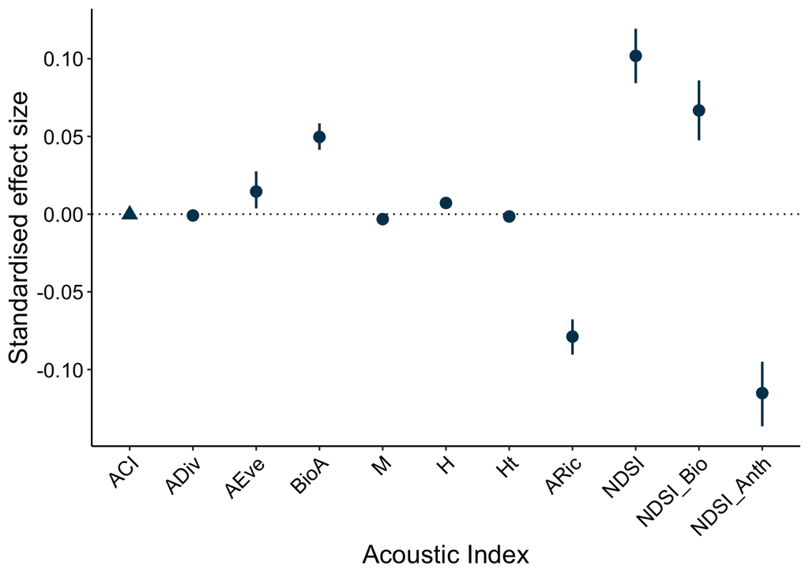

```r
# Fig. 2a
ggplot(data = Stats_Out[Stats_Out$Subset %in% "All",],
       mapping = aes(x = Index,
                     y = Diff,
                     ymin = Diff_lo,
                     ymax = Diff_up),
       group = Index) +
  ylab("Standardised effect size") +
  xlab("Acoustic Index") +
  theme_classic() +
  theme(text = element_text(size = 16),
        axis.text = element_text(colour = "black"),
        axis.text.x = element_text(angle = 45, hjust=1),
        strip.background = element_blank(),
        legend.position = "bottom") +
  geom_hline(yintercept = 0,lty = 3) +
  geom_pointrange(mapping = aes(shape = Sig),
                  col = '#003F5C',
             size = 0.75,
             show.legend = FALSE) +
  scale_shape_manual(values = c(17,16),
                     guide = FALSE)
```

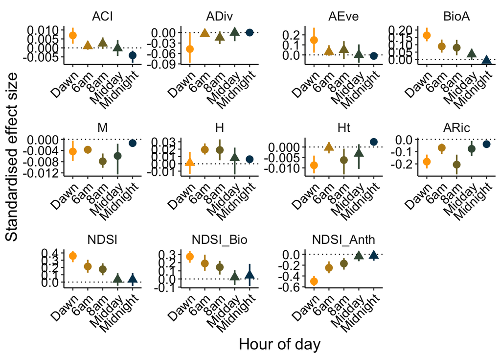

```r
# Fig. 4
ggplot(data = Stats_Out[Stats_Out$Subset %!in% "All",],
       mapping = aes(x = Subset,
                     y = Diff,
                     ymin = Diff_lo,
                     ymax = Diff_up),
       group = Index) +
  ylab("Standardised effect size") +
  xlab("Hour of day") +
  theme_classic() +
  theme(text = element_text(size = 16),
        axis.text = element_text(colour = "black"),
        axis.text.x = element_text(angle = 45, hjust=1),
        strip.background = element_blank(),
        legend.position = "bottom") +
  geom_hline(yintercept = 0,lty = 3) +
  geom_pointrange(mapping = aes(col = Subset,shape = Sig),
             size = 0.75,
             show.legend = FALSE) +
  facet_wrap(. ~ Index,
             scales = 'free') +
  scale_shape_manual(values = c(17,16),
                     guide = FALSE) +
  scale_color_manual(values = colramp(5))
```

## Temporal variability

```r
Var_Out<-data.frame("Index"=rep(as.character(colnames(Standard)[c(2:12)]),each=12),
                    "Subset"=rep(rep(c("All","Dawn","6am","Midnight","Midday","8am"),each=2),11),
                    "Period"=rep(as.character(c("Lockdown","Post-lockdown")),132),
                    'Var'=NA,'SD'=NA,"Var_lo"=NA,"Var_up"=NA,"N"=NA)
```

Let’s fit simple Acoustic index ~ time models without considering differences across month. Then temporal variability is calculated as the mean of the absolute residuals from the slope of these models:

Dawn Chorus:

```r
# generate models per period x index
model.out_lock<-list()
model.out_post<-list()

for (i in 1:11) {

  Lock_data<-Dawn.chorus[Dawn.chorus$Period %in% "Lockdown",1+i]
  Post_data<-Dawn.chorus[Dawn.chorus$Period %in% "Post-lockdown",1+i]

  model.out_lock[[i]]<-glm(Lock_data ~ time,
                           data = Dawn.chorus[Dawn.chorus$Period %in% "Lockdown",],
                           family = beta_family(link = "logit"))

  model.out_post[[i]]<-glm(Post_data ~ time,
                           data = Dawn.chorus[Dawn.chorus$Period %in% "Post-lockdown",],
                           family = beta_family(link = "logit"))

  # get means and sds of abs model residuals as values of temporal variability
  Var_Out$Var[Var_Out$Period %in% "Lockdown" & Var_Out$Subset %in% "Dawn" &
                   Var_Out$Index %in% unique(Var_Out$Index)[i]]<-mean(abs(model.out_lock[[i]]$residuals))
  Var_Out$SD[Var_Out$Period %in% "Lockdown" & Var_Out$Subset %in% "Dawn" &
                   Var_Out$Index %in% unique(Var_Out$Index)[i]]<-sd(abs(model.out_lock[[i]]$residuals))
  Var_Out$N[Var_Out$Period %in% "Lockdown" & Var_Out$Subset %in% "Dawn" &
                   Var_Out$Index %in% unique(Var_Out$Index)[i]]<-length(model.out_lock[[i]]$residuals)
  Var_Out$Var[Var_Out$Period %in% "Post-lockdown" & Var_Out$Subset %in% "Dawn" &
                   Var_Out$Index %in% unique(Var_Out$Index)[i]]<-mean(abs(model.out_post[[i]]$residuals))
  Var_Out$SD[Var_Out$Period %in% "Post-lockdown" & Var_Out$Subset %in% "Dawn" &
                   Var_Out$Index %in% unique(Var_Out$Index)[i]]<-sd(abs(model.out_post[[i]]$residuals))
  Var_Out$N[Var_Out$Period %in% "Post-lockdown" & Var_Out$Subset %in% "Dawn" &
                   Var_Out$Index %in% unique(Var_Out$Index)[i]]<-length(model.out_post[[i]]$residuals)
}
```

Get confidence intervals:

```r
Var_Out$Var_lo<-Var_Out$Var-Var_Out$SD
Var_Out$Var_up<-Var_Out$Var+Var_Out$SD
```

```r
Var_Out$Subset<-parse_factor(as.character(Var_Out$Subset),
                             levels = c("All","Dawn","6am","8am","Midday","Midnight"),
                             ordered = T)

Var_Out$Index<-parse_factor(as.character(Var_Out$Index),
                            levels = c("ACI","ADiv","AEve","BioA","M","H","Ht","ARic","NDSI","NDSI_Bio","NDSI_Anth"),
                            ordered = T)

Var_Out$Period<-parse_factor(as.character(Var_Out$Period),
                             levels = c("Lockdown","Post-lockdown"),
                             ordered = T)

Var_Out$Var_lo[Var_Out$Var_lo < 0]<-0 #NB: since negative Temporal variability values are meaningless, we'll coerce these into zeros:
```

## Confidence interval for difference in variability

Finally, let’s get a confidence interval around the difference between 2 means with standard deviations. Set up out output:

```r
Var_SES<-Stats_Out[,c(1,2,5:8)]
Var_SES[,c(3:6)]<-NA
```

Calculate standardised effect sizes for the temporal variability of the difference between lockdown and post-lockdown:

```r
z<-1.96 # this is the critical z value for 95% confidence

for (i in 1:nrow(Var_SES)) {

  x_lock<-Var_Out$Var[Var_Out$Period %in% "Lockdown"][i]
  x_post<-Var_Out$Var[Var_Out$Period %in% "Post-lockdown"][i]
  sd_lock<-Var_Out$SD[Var_Out$Period %in% "Lockdown"][i]
  sd_post<-Var_Out$SD[Var_Out$Period %in% "Post-lockdown"][i]
  N_lock<-Var_Out$N[Var_Out$Period %in% "Lockdown"][i]
  N_post<-Var_Out$N[Var_Out$Period %in% "Post-lockdown"][i]
  Diff<-x_lock-x_post
  Err<-sqrt(((sd_lock^2)/N_lock)+((sd_post^2)/N_post))*z
  Var_SES$Diff[i]<-Diff
  Var_SES$Diff_lo[i]<-Diff-Err
  Var_SES$Diff_up[i]<-Diff+Err

}
```

Get whether these values cross zero:

```r
Var_SES$Sig<-0
Var_SES$Sig[sign(Var_SES$Diff_lo) + sign(Var_SES$Diff_up) != 0]<-1
```

# Plot the results

```r
Var_SES$Subset<-parse_factor(as.character(Var_SES$Subset),
                             levels = c("All","Dawn","6am","8am","Midday","Midnight"),
                             ordered = T)

Var_SES$Index<-parse_factor(as.character(Var_SES$Index),
                            levels = c("ACI","ADiv","AEve","BioA","M","H","Ht","ARic","NDSI","NDSI_Bio","NDSI_Anth"),
                            ordered = T)

Var_SES$Sig<-parse_factor(as.character(Var_SES$Sig),
                          levels = c("0","1"),
                          ordered = F)
```

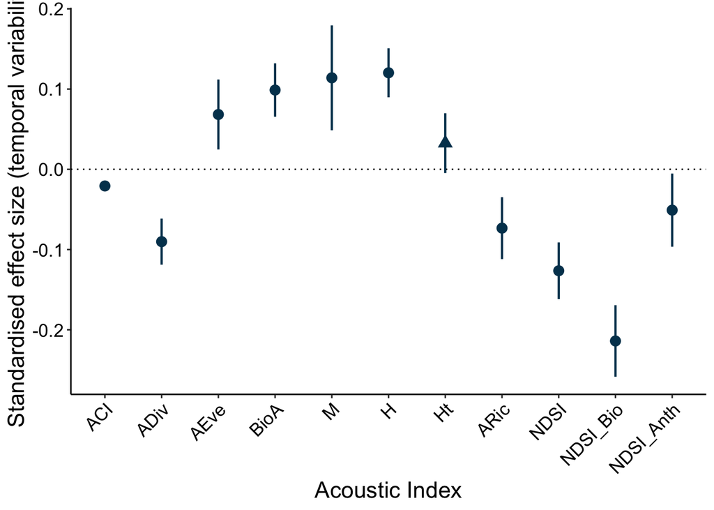

```r
# Fig. 2b
ggplot(data = Var_SES[Var_SES$Subset %in% "All",],
       mapping = aes(x = Index,
                     y = Diff,
                     ymin = Diff_lo,
                     ymax = Diff_up),
       group = Index) +
  ylab("Standardised effect size (temporal variability)") +
  xlab("Acoustic Index") +
  theme_classic() +
  theme(text = element_text(size = 16),
        axis.text = element_text(colour = "black"),
        axis.text.x = element_text(angle = 45, hjust=1),
        strip.background = element_blank(),
        legend.position = "bottom") +
  geom_hline(yintercept = 0,lty = 3) +
  geom_pointrange(mapping = aes(shape = Sig),
                  col = '#003F5C',
             size = 0.75,
             show.legend = FALSE) +
  scale_shape_manual(values = c(17,16),
                     guide = FALSE)
```

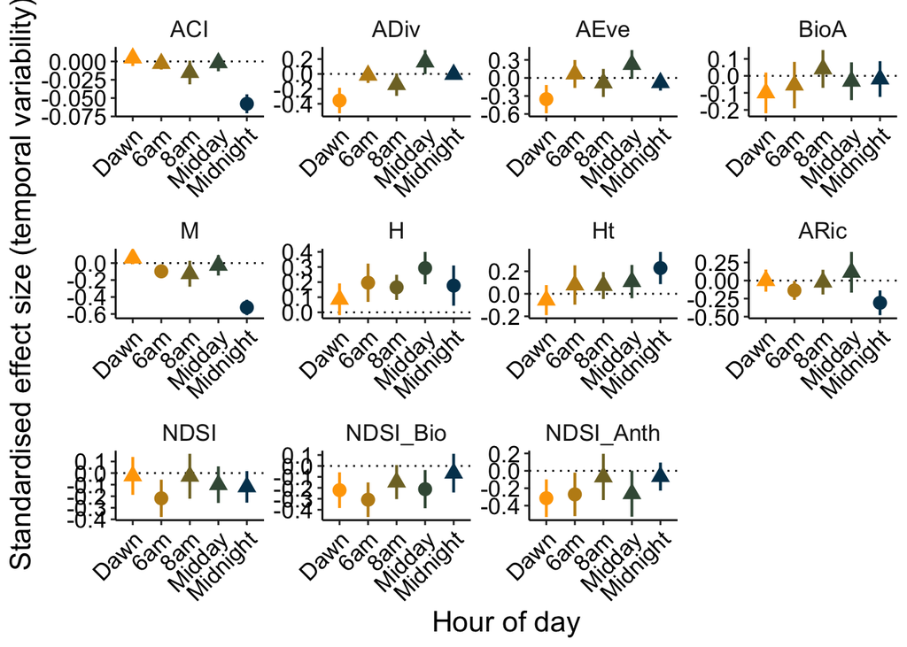

```r
# Fig. S4
ggplot(data = Var_SES[Var_SES$Subset %!in% "All",],
       mapping = aes(x = Subset,
                     y = Diff,
                     ymin = Diff_lo,
                     ymax = Diff_up),
       group = Index) +
  ylab("Standardised effect size (temporal variability)") +
  xlab("Hour of day") +
  theme_classic() +
  theme(text = element_text(size = 16),
        axis.text = element_text(colour = "black"),
        axis.text.x = element_text(angle = 45, hjust=1),
        strip.background = element_blank(),
        legend.position = "bottom") +
  geom_hline(yintercept = 0,lty = 3) +
  geom_pointrange(mapping = aes(col = Subset,shape = Sig),
             size = 0.75,
             show.legend = FALSE) +
  facet_wrap(. ~ Index,
             scales = 'free') +
  scale_shape_manual(values = c(17,16),
                     guide = FALSE) +
  scale_color_manual(values = colramp(5))
```

<sub>Fin.</sub>